# Ford GoBike System Data

## by Saeed Falan

### *Ramallah, Palestine*

## Why am I doing this Analysis?

> This data set includes information about individual rides made in a bike-sharing system covering the greater San Francisco Bay area.

> Note that this dataset will require some data wrangling in order to make it tidy for analysis. There are multiple cities , and multiple data files will need to be joined together

> *Ford goBike Data is available in this link [**Ford goBike Data Download**](https://s3.amazonaws.com/fordgobike-data/index.html)*

## Investigation Overview

### Highlights

**1. How does subscibers and customers behave differently?**

> Subscribers' rides take place around both morning commute time and evening commute time. On the contrary, customers' rides take place the most during weekend, which represents the main purpose for the user type is different. The former is for convenience around commute time and the latter is more likely for leisure.

**2. Which age group favors e-bike more?**

> Suprisingly, 10 to 20 years user group seems to show the most interest in the e-bike, seeing that the percentage of e-bike rides of all the rides by 10 to 20 years old users is around 10%. Also, the younger a rider is, the more likely the rider would be fond of electric bike rides.

**3. What are the most popular docks for 'Bike share for all' members?**

> 'Bike share for all' program is a subscription model for low income bay area residents. Unlike most popular docks for all members gathered around financial distinct and market street, the popular docks for 'Bike share for all' members are sqreaded especially around bart station or caltrain station, even though those are quite further away from market street, such as 24th street bart station. I guess it's because low income people tend to travel further from south bay or east bay and they might take public transportation to work around San Fancisco area.

## Dataset Overview

### Data

> This project used the following dataset, which are available in (**Datasource**: [Ford goBike](https://s3.amazonaws.com/fordgobike-data/index.html) )

> **The dataset is a huge file so I compressed the file. So, before running my analysis, you should decompress the file.**

```python
# import all packages and set plots to be embedded inline
from requests import get
from os import path, getcwd, makedirs, listdir
from io import BytesIO
from zipfile import ZipFile

import pandas as pd
import numpy as np
import matplotlib
from matplotlib import pyplot as plt
import matplotlib.ticker as tick
import seaborn as sns
import datetime
import math
import calendar
import cufflinks as cf

import warnings
warnings.filterwarnings('ignore')

from IPython.display import Image


from bokeh.io import output_file, show, output_notebook
from bokeh.models import ColumnDataSource, GMapOptions
from bokeh.plotting import gmap, figure

%matplotlib inline
%load_ext rpy2.ipython
```

```
The rpy2.ipython extension is already loaded. To reload it, use:
  %reload_ext rpy2.ipython
```

```python
# load in the dataset into a pandas dataframe
df = pd.read_csv('data.csv')
df.info()
```

```
<class 'pandas.core.frame.DataFrame'>
RangeIndex: 1538086 entries, 0 to 1538085
Data columns (total 18 columns):
Unnamed: 0                 1538086 non-null int64
Unnamed: 0.1               519700 non-null float64
bike_id                    1538086 non-null int64
bike_share_for_all_trip    1018386 non-null object
duration_sec               1538086 non-null int64
end_station_id             1532841 non-null float64
end_station_latitude       1538086 non-null float64
end_station_longitude      1538086 non-null float64
end_station_name           1532841 non-null object
end_time                   1538086 non-null object
member_birth_year          1400419 non-null float64
member_gender              1400760 non-null object
start_station_id           1532841 non-null float64
start_station_latitude     1538086 non-null float64
start_station_longitude    1538086 non-null float64
start_station_name         1532841 non-null object
start_time                 1538086 non-null object
user_type                  1538086 non-null object
dtypes: float64(8), int64(3), object(7)
memory usage: 211.2+ MB
```

```python
df.head(1)
```

|  | Unnamed: 0 | Unnamed: 0.1 | bike_id | bike_share_for_all_trip | duration_sec | end_station_id | end_station_latitude | end_station_longitude | end_station_name | end_time | member_birth_year | member_gender | start_station_id | start_station_latitude | start_station_longitude | start_station_name | start_time | user_type |
| --- | --- | --- | --- | --- | --- | --- | --- | --- | --- | --- | --- | --- | --- | --- | --- | --- | --- | --- |
| 0 | 0 | 0.0 | 96 | NaN | 80110 | 43.0 | 37.778768 | -122.415929 | San Francisco Public Library (Grove St at Hyde... | 2018-01-01 15:12:50.2450 | 1987.0 | Male | 74.0 | 37.776435 | -122.426244 | Laguna St at Hayes St | 2017-12-31 16:57:39.6540 | Customer |

```python
df.tail(1)
```

[output not shown]

```python
df['member_age'] = 2018-df['member_birth_year']
```

```python
df = df[df['member_age']<=60]
```

```python
df['member_age'].mean()
```

```
35.37610017731796
```

```python
df.drop(['Unnamed: 0', 'member_birth_year'], axis=1, inplace=True)
```

```python
df['start_time']=pd.to_datetime(df['start_time'])
df['end_time']=pd.to_datetime(df['end_time'])
```

```python
df['start_time_date']=df['start_time'].dt.date
df['end_time_date']=df['end_time'].dt.date
```

```python
df['start_time_year_month']=df['start_time'].map(lambda x: x.strftime('%Y-%m'))
df['end_time_year_month']=df['end_time'].map(lambda x: x.strftime('%Y-%m'))
```

```python
df['start_time_year_month_renamed'] = df['start_time'].dt.strftime('%y' + '-' + '%m')
```

```python
df['start_time_year']=df['start_time'].dt.year.astype(int)
df['end_time_year']=df['end_time'].dt.year.astype(int)
```

```python
df['start_time_month']=df['start_time'].dt.month.astype(int)
df['end_time_month']=df['end_time'].dt.month.astype(int)
```

```python
df['member_age_bins'] = df['member_age'].apply(lambda x: '10 - 20' if 10<x<=20
                                                  else '20 - 30' if 20<x<=30
                                                  else '30 - 40' if 30<x<=40
                                                  else '40 - 50' if 40<x<=50
                                                  else '50 - 60' if 50<x<=60
                                                  else x)
```

```python
def transform_axis_fmt(tick_val, pos):
    if tick_val >= 1000:
        val = int(tick_val/1000)
        return '{:d}K'.format(val)
    elif tick_val >= 1000000:
        val = int(tick_val/1000000)
        return '{:d}M'.format(val)
    else:
        return int(tick_val)
```

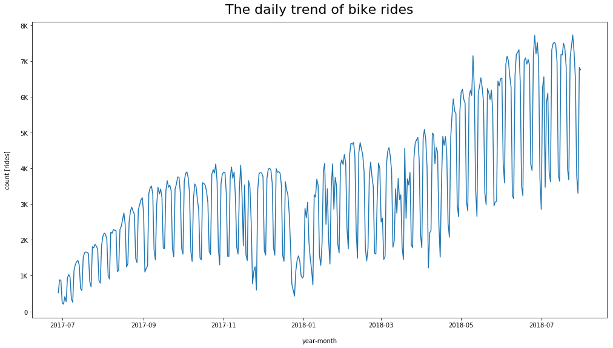

```python
df.groupby('start_time_date').agg({'bike_id':'count'}).plot(style='-', legend=False, figsize=(17,9))
plt.title('The daily trend of bike rides', fontsize=22, y=1.015)
plt.xlabel('year-month', labelpad=16)
plt.ylabel('count [rides]', labelpad=16)
ax = plt.gca()
ax.yaxis.set_major_formatter(tick.FuncFormatter(transform_axis_fmt))
plt.savefig('image/image01.png');
```

### The daily trend of bike rides

> Compared to 2017 July 1st, where daily rides were less than 1000, it increased to more than 5000 after a year (2018 July lst) There is huge decrease around January 2018 because it's too cold. Also, There is weekly ups and downs.

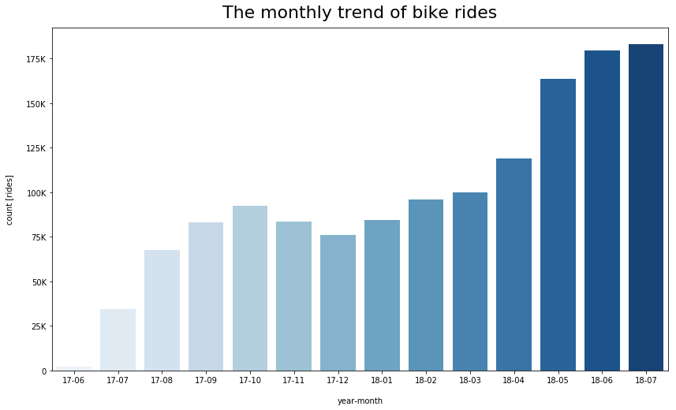

```python
plt.figure(figsize=(14,8))
sns.countplot(x='start_time_year_month_renamed', palette="Blues", data=df.sort_values(by='start_time_year_month_renamed'))
plt.title('The monthly trend of bike rides', fontsize=22, y=1.015)
plt.xlabel('year-month', labelpad=16)
plt.ylabel('count [rides]', labelpad=16)
ax = plt.gca()
ax.yaxis.set_major_formatter(tick.FuncFormatter(transform_axis_fmt))
plt.savefig('image/image02.png');
```

### The monthly trend of bike rides

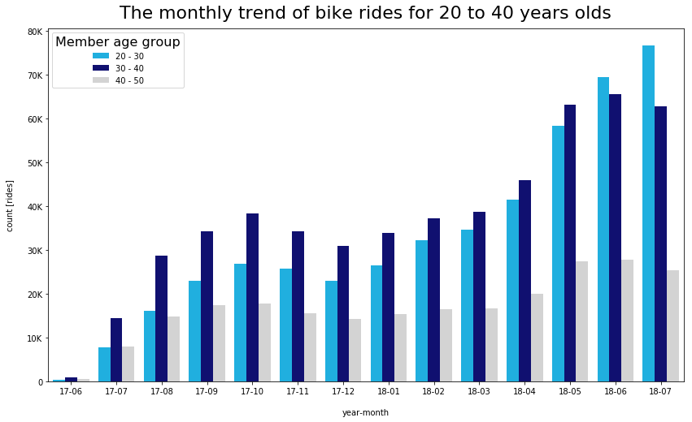

```python
plt.figure(figsize=(14,8))
my_palette = {'20 - 30': 'deepskyblue', '30 - 40': 'navy', '40 - 50': 'lightgrey'}
ax = sns.countplot(x='start_time_year_month_renamed', hue='member_age_bins', palette=my_palette, data=df[df['member_age_bins'].isin(['20 - 30', '30 - 40', '40 - 50'])].sort_values(by=['start_time_year_month_renamed', 'member_age_bins']))
plt.title('The monthly trend of bike rides for 20 to 40 years olds', fontsize=22, y=1.015)
plt.xlabel('year-month', labelpad=16)
plt.ylabel('count [rides]', labelpad=16)
leg = ax.legend()
leg.set_title('Member age group',prop={'size':16})
ax = plt.gca()
ax.yaxis.set_major_formatter(tick.FuncFormatter(transform_axis_fmt))
plt.savefig('image/image03.png');
```

### The monthly trend of bike rides for 20 to 40 years olds

> 20's users are rapidly growing compared to other user groups. When the service first started 30's user were dominant, however in a year 20's users became on par of 30's users or even more recently.

```python
trip_by_age_df = df.groupby('member_age_bins').agg({'bike_id':'count'})
```

```python
trip_by_age_df['perc'] = (trip_by_age_df['bike_id']/trip_by_age_df['bike_id'].sum())*100
```

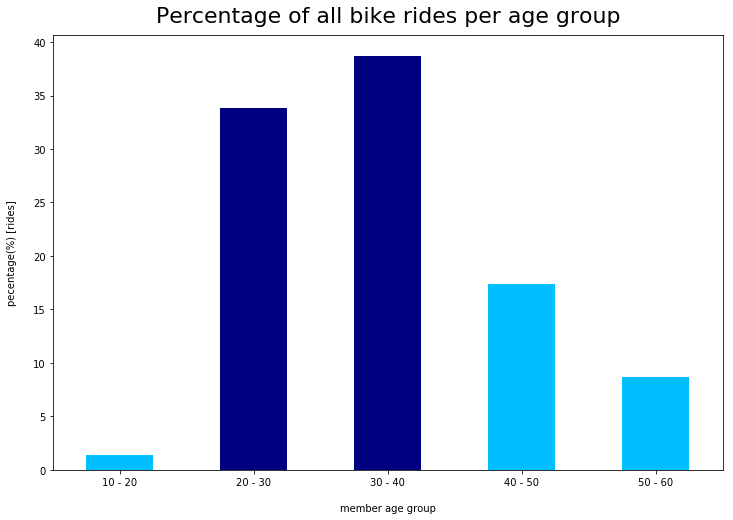

```python
new_color = ['deepskyblue', 'navy', 'navy', 'deepskyblue', 'deepskyblue']
trip_by_age_df['perc'].plot(kind='bar', color=new_color, figsize=(12,8))
plt.title('Percentage of all bike rides per age group', fontsize=22, y=1.015)
plt.xlabel('member age group', labelpad=16)
plt.ylabel('pecentage(%) [rides]', labelpad=16)
plt.xticks(rotation=360)
plt.savefig('image/image04.png');
```

### Percentage of all bike rides per age group

> 20 to 40 years old people took the more than 70% of bike rides.  
> Among those, 30 to 40 years old people's rides account for 40% of all bike rides.

```python
user_type_count_per_year_df = df.groupby(["start_time_year_month_renamed", "user_type"]).size().reset_index()
```

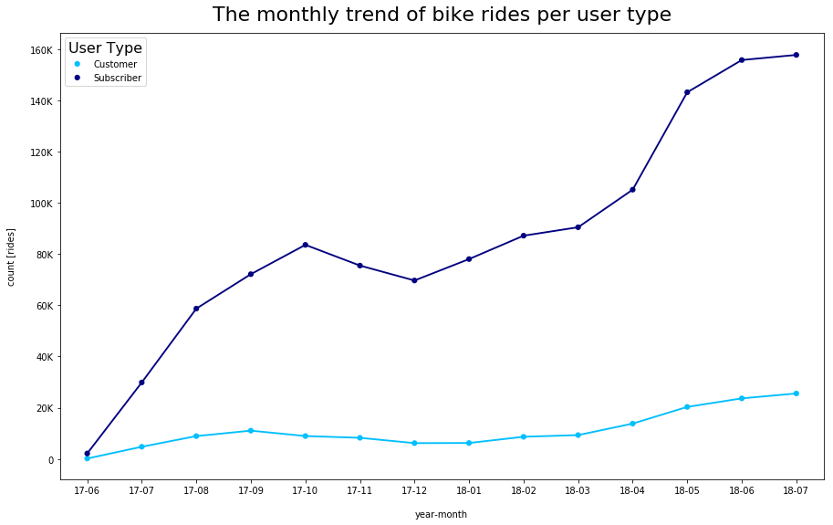

```python
plt.figure(figsize=(15,9))
my_palette = {'Subscriber':'navy', 'Customer':'deepskyblue'}
ax = sns.pointplot(x='start_time_year_month_renamed', y=0, hue='user_type', palette=my_palette, scale=.7, data=user_type_count_per_year_df)
plt.title('The monthly trend of bike rides per user type', fontsize=22, y=1.015)
plt.xlabel('year-month', labelpad=16)
plt.ylabel('count [rides]', labelpad=16)
leg = ax.legend()
leg.set_title('User Type',prop={'size':16})
ax = plt.gca()
ax.yaxis.set_major_formatter(tick.FuncFormatter(transform_axis_fmt))
plt.savefig('image/image08.png');
```

## Conclusion

> Generally, around 90% of rides take place on weekday. Also, more than 70% of users are in 20 to 40 years old age(when mean age is 35). Plus, 76% of bike rides by male. Moreover, the peak bike rides time for all members is around commute time(a quarter of the total rides happen exactly at 8am and 5pm). Seeing all these, the user persona of the Ford goBike can be inferred as a 35 old man who is working for tech company around market street.

> 88% of rides are from subscribers and the rest 12% are from customers. Also, Average trip duration for subscribers are 12minutes, which is about a third of customers'. Since bike rides has no cost on each ride, it's recommendable to encourage subscription. Subscribers' rides take place around commute time, on the contrary customers' rides take place the most during weekend, which represents the main purpose for the user type is different. The former is for convenience around commute time and the latter is more likely for leisure.

> 'Bike share for all' program is a subscription model for low income bay area residents. Unlike for all members where there were two peak time around both morning commute time and evening commute time, there is only one peak time for 'Bike share for all' members around 5pm. In addition, unlike most popular docks for all members gathered around financial distinct and market street, the popular docks for 'Bike share for all' members are sqreaded around bart station or caltrain station, even when it is further away from market street, such as 24th street bart station. Finally, it seems that 40 to 50 years old age group use the service the most.

> After Ford goBike did a pilot launch of e-bike on April 24th 2018, there have been quite a lot of electric bike rides as well, which reached to 10% of daily rides at the end of July 2018. However, daily electric bike rides is on downward trend. But, suprisingly, 10 to 20 years user group seems to show the most interest in the e-bike, seeing that the percentage of e-bike rides of all the rides is around 10%. Also, the younger a rider is, the more likely the rider would be fond of electric bike rides.